# FordGoBike Exploration

## Preliminary Wrangling

This document explores a dataset containing information on Ford Go Bikes in the California Bay area, such as the distance and duration of travel, amongst other attributes.

```python
import numpy as np
import pandas as pd
import matplotlib.pyplot as plt
import seaborn as sb

%matplotlib inline
```

```python
# Use pandas read function to load in the dataset
ford = pd.read_csv('201902-fordgobike-tripdata.csv')
```

```python
# Taking a first look at the dataset, as well as a more in-depth view by concurrently viewing the file in Excel.
ford
```

|  | duration_sec | start_time | end_time | start_station_id | start_station_name | start_station_latitude | start_station_longitude | end_station_id | end_station_name | end_station_latitude | end_station_longitude | bike_id | user_type | member_birth_year | member_gender | bike_share_for_all_trip |
| --- | --- | --- | --- | --- | --- | --- | --- | --- | --- | --- | --- | --- | --- | --- | --- | --- |
| 0 | 52185 | 2019-02-28 17:32:10.1450 | 2019-03-01 08:01:55.9750 | 21.0 | Montgomery St BART Station (Market St at 2nd St) | 37.789625 | -122.400811 | 13.0 | Commercial St at Montgomery St | 37.794231 | -122.402923 | 4902 | Customer | 1984.0 | Male | No |
| 1 | 42521 | 2019-02-28 18:53:21.7890 | 2019-03-01 06:42:03.0560 | 23.0 | The Embarcadero at Steuart St | 37.791464 | -122.391034 | 81.0 | Berry St at 4th St | 37.775880 | -122.393170 | 2535 | Customer | NaN | NaN | No |
| 2 | 61854 | 2019-02-28 12:13:13.2180 | 2019-03-01 05:24:08.1460 | 86.0 | Market St at Dolores St | 37.769305 | -122.426826 | 3.0 | Powell St BART Station (Market St at 4th St) | 37.786375 | -122.404904 | 5905 | Customer | 1972.0 | Male | No |
| 3 | 36490 | 2019-02-28 17:54:26.0100 | 2019-03-01 04:02:36.8420 | 375.0 | Grove St at Masonic Ave | 37.774836 | -122.446546 | 70.0 | Central Ave at Fell St | 37.773311 | -122.444293 | 6638 | Subscriber | 1989.0 | Other | No |
| 4 | 1585 | 2019-02-28 23:54:18.5490 | 2019-03-01 00:20:44.0740 | 7.0 | Frank H Ogawa Plaza | 37.804562 | -122.271738 | 222.0 | 10th Ave at E 15th St | 37.792714 | -122.248780 | 4898 | Subscriber | 1974.0 | Male | Yes |
| ... | ... | ... | ... | ... | ... | ... | ... | ... | ... | ... | ... | ... | ... | ... | ... | ... |
| 183407 | 480 | 2019-02-01 00:04:49.7240 | 2019-02-01 00:12:50.0340 | 27.0 | Beale St at Harrison St | 37.788059 | -122.391865 | 324.0 | Union Square (Powell St at Post St) | 37.788300 | -122.408531 | 4832 | Subscriber | 1996.0 | Male | No |
| 183408 | 313 | 2019-02-01 00:05:34.7440 | 2019-02-01 00:10:48.5020 | 21.0 | Montgomery St BART Station (Market St at 2nd St) | 37.789625 | -122.400811 | 66.0 | 3rd St at Townsend St | 37.778742 | -122.392741 | 4960 | Subscriber | 1984.0 | Male | No |
| 183409 | 141 | 2019-02-01 00:06:05.5490 | 2019-02-01 00:08:27.2200 | 278.0 | The Alameda at Bush St | 37.331932 | -121.904888 | 277.0 | Morrison Ave at Julian St | 37.333658 | -121.908586 | 3824 | Subscriber | 1990.0 | Male | Yes |
| 183410 | 139 | 2019-02-01 00:05:34.3600 | 2019-02-01 00:07:54.2870 | 220.0 | San Pablo Ave at MLK Jr Way | 37.811351 | -122.273422 | 216.0 | San Pablo Ave at 27th St | 37.817827 | -122.275698 | 5095 | Subscriber | 1988.0 | Male | No |
| 183411 | 271 | 2019-02-01 00:00:20.6360 | 2019-02-01 00:04:52.0580 | 24.0 | Spear St at Folsom St | 37.789677 | -122.390428 | 37.0 | 2nd St at Folsom St | 37.785000 | -122.395936 | 1057 | Subscriber | 1989.0 | Male | No |

183412 rows × 16 columns

```python
# Take a look at the data types of the columns, as well as the null value information.
ford.info()
```

```
<class 'pandas.core.frame.DataFrame'>
RangeIndex: 183412 entries, 0 to 183411
Data columns (total 16 columns):
 #   Column                   Non-Null Count   Dtype
---  ------                   --------------   -----
 0   duration_sec             183412 non-null  int64
 1   start_time               183412 non-null  object
 2   end_time                 183412 non-null  object
 3   start_station_id         183215 non-null  float64
 4   start_station_name       183215 non-null  object
 5   start_station_latitude   183412 non-null  float64
 6   start_station_longitude  183412 non-null  float64
 7   end_station_id           183215 non-null  float64
 8   end_station_name         183215 non-null  object
 9   end_station_latitude     183412 non-null  float64
 10  end_station_longitude    183412 non-null  float64
 11  bike_id                  183412 non-null  int64
 12  user_type                183412 non-null  object
 13  member_birth_year        175147 non-null  float64
 14  member_gender            175147 non-null  object
 15  bike_share_for_all_trip  183412 non-null  object
dtypes: float64(7), int64(2), object(7)
memory usage: 22.4+ MB
```

```python
# We have to change the columns indicated below to the correct datatype before contnuing.
ford['start_time'] = pd.to_datetime(ford['start_time'])
ford['end_time'] = pd.to_datetime(ford['end_time'])
ford['start_station_name'] = ford['start_station_name'].astype('category')
ford['end_station_name'] = ford['end_station_name'].astype('category')
ford['user_type'] = ford['user_type'].astype('category')
ford['member_gender'] = ford['member_gender'].astype('category')
ford['bike_share_for_all_trip'] = ford['bike_share_for_all_trip'].astype('category')
ford['start_station_id'] = ford['start_station_id'].astype('str')
ford['end_station_id'] = ford['end_station_id'].astype('str')
ford['bike_id'] = ford['bike_id'].astype('str')
```

```python
# We want to create new columns to aid visualizations
ford['start_hour'] = ford.start_time.dt.strftime('%H')
ford['start_day'] = ford.start_time.dt.strftime('%A')
```

```python
# create an age column, rather than birth year
ford['member_age'] = 2020 - ford['member_birth_year']
```

```python
# Changing the datatype of our columns
ford['start_hour'] = ford['start_hour'].astype(float)
ford['start_day'] = ford['start_day'].astype('category')
```

```python
# removing null values
ford_one = ford[ford['member_birth_year'].isnull()==False]
ford_upd = ford_one[ford_one['start_station_name'].isnull()==False]
```

```python
# upon reflection with the histogram for age distribution below, I have decided to limit the age to 80 to eliminate outliers.
ford_clean = ford_upd[ford_upd['member_age']<81]
```

```python
#searching for duplicate columns we find none.
ford_clean[ford_clean.duplicated()]
```

|  | duration_sec | start_time | end_time | start_station_id | start_station_name | start_station_latitude | start_station_longitude | end_station_id | end_station_name | end_station_latitude | end_station_longitude | bike_id | user_type | member_birth_year | member_gender | bike_share_for_all_trip | start_hour | start_day | member_age |
| --- | --- | --- | --- | --- | --- | --- | --- | --- | --- | --- | --- | --- | --- | --- | --- | --- | --- | --- | --- |

```python
ford_clean.info()
```

```
<class 'pandas.core.frame.DataFrame'>
Int64Index: 174749 entries, 0 to 183411
Data columns (total 19 columns):
 #   Column                   Non-Null Count   Dtype
---  ------                   --------------   -----
 0   duration_sec             174749 non-null  int64
 1   start_time               174749 non-null  datetime64[ns]
 2   end_time                 174749 non-null  datetime64[ns]
 3   start_station_id         174749 non-null  object
 4   start_station_name       174749 non-null  category
 5   start_station_latitude   174749 non-null  float64
 6   start_station_longitude  174749 non-null  float64
 7   end_station_id           174749 non-null  object
 8   end_station_name         174749 non-null  category
 9   end_station_latitude     174749 non-null  float64
 10  end_station_longitude    174749 non-null  float64
 11  bike_id                  174749 non-null  object
 12  user_type                174749 non-null  category
 13  member_birth_year        174749 non-null  float64
 14  member_gender            174749 non-null  category
 15  bike_share_for_all_trip  174749 non-null  category
 16  start_hour               174749 non-null  float64
 17  start_day                174749 non-null  category
 18  member_age               174749 non-null  float64
dtypes: category(6), datetime64[ns](2), float64(7), int64(1), object(3)
memory usage: 20.0+ MB
```

```python
# the describe function gives us a feel for the distribution of the data.
ford.describe()
```

|  | duration_sec | start_station_latitude | start_station_longitude | end_station_latitude | end_station_longitude | member_birth_year | start_hour | member_age |
| --- | --- | --- | --- | --- | --- | --- | --- | --- |
| count | 183412.000000 | 183412.000000 | 183412.000000 | 183412.000000 | 183412.000000 | 175147.000000 | 183412.000000 | 175147.000000 |
| mean | 726.078435 | 37.771223 | -122.352664 | 37.771427 | -122.352250 | 1984.806437 | 13.458421 | 35.193563 |
| std | 1794.389780 | 0.099581 | 0.117097 | 0.099490 | 0.116673 | 10.116689 | 4.724978 | 10.116689 |
| min | 61.000000 | 37.317298 | -122.453704 | 37.317298 | -122.453704 | 1878.000000 | 0.000000 | 19.000000 |
| 25% | 325.000000 | 37.770083 | -122.412408 | 37.770407 | -122.411726 | 1980.000000 | 9.000000 | 28.000000 |
| 50% | 514.000000 | 37.780760 | -122.398285 | 37.781010 | -122.398279 | 1987.000000 | 14.000000 | 33.000000 |
| 75% | 796.000000 | 37.797280 | -122.286533 | 37.797320 | -122.288045 | 1992.000000 | 17.000000 | 40.000000 |
| max | 85444.000000 | 37.880222 | -121.874119 | 37.880222 | -121.874119 | 2001.000000 | 23.000000 | 142.000000 |

```python
# exploring how many values for duration make up large numbers (~1% are more than 3000 seconds.)
ford_clean[ford_clean['duration_sec']>3000]
```

|  | duration_sec | start_time | end_time | start_station_id | start_station_name | start_station_latitude | start_station_longitude | end_station_id | end_station_name | end_station_latitude | end_station_longitude | bike_id | user_type | member_birth_year | member_gender | bike_share_for_all_trip | start_hour | start_day | member_age |
| --- | --- | --- | --- | --- | --- | --- | --- | --- | --- | --- | --- | --- | --- | --- | --- | --- | --- | --- | --- |
| 0 | 52185 | 2019-02-28 17:32:10.145 | 2019-03-01 08:01:55.975 | 21.0 | Montgomery St BART Station (Market St at 2nd St) | 37.789625 | -122.400811 | 13.0 | Commercial St at Montgomery St | 37.794231 | -122.402923 | 4902 | Customer | 1984.0 | Male | No | 17.0 | Thursday | 36.0 |
| 2 | 61854 | 2019-02-28 12:13:13.218 | 2019-03-01 05:24:08.146 | 86.0 | Market St at Dolores St | 37.769305 | -122.426826 | 3.0 | Powell St BART Station (Market St at 4th St) | 37.786375 | -122.404904 | 5905 | Customer | 1972.0 | Male | No | 12.0 | Thursday | 48.0 |
| 3 | 36490 | 2019-02-28 17:54:26.010 | 2019-03-01 04:02:36.842 | 375.0 | Grove St at Masonic Ave | 37.774836 | -122.446546 | 70.0 | Central Ave at Fell St | 37.773311 | -122.444293 | 6638 | Subscriber | 1989.0 | Other | No | 17.0 | Thursday | 31.0 |
| 55 | 3478 | 2019-02-28 22:39:35.020 | 2019-02-28 23:37:33.342 | 11.0 | Davis St at Jackson St | 37.797280 | -122.398436 | 11.0 | Davis St at Jackson St | 37.797280 | -122.398436 | 1846 | Subscriber | 1995.0 | Male | No | 22.0 | Thursday | 25.0 |
| 56 | 3140 | 2019-02-28 22:44:53.503 | 2019-02-28 23:37:14.090 | 11.0 | Davis St at Jackson St | 37.797280 | -122.398436 | 11.0 | Davis St at Jackson St | 37.797280 | -122.398436 | 3040 | Subscriber | 1983.0 | Female | No | 22.0 | Thursday | 37.0 |
| ... | ... | ... | ... | ... | ... | ... | ... | ... | ... | ... | ... | ... | ... | ... | ... | ... | ... | ... | ... |
| 181707 | 3980 | 2019-02-01 07:58:36.852 | 2019-02-01 09:04:57.425 | 141.0 | Valencia St at Cesar Chavez St | 37.747998 | -122.420219 | 15.0 | San Francisco Ferry Building (Harry Bridges Pl... | 37.795392 | -122.394203 | 5454 | Subscriber | 1975.0 | Female | Yes | 7.0 | Friday | 45.0 |
| 181850 | 3497 | 2019-02-01 07:58:41.447 | 2019-02-01 08:56:58.634 | 141.0 | Valencia St at Cesar Chavez St | 37.747998 | -122.420219 | 15.0 | San Francisco Ferry Building (Harry Bridges Pl... | 37.795392 | -122.394203 | 5226 | Subscriber | 1973.0 | Male | Yes | 7.0 | Friday | 47.0 |
| 182133 | 6086 | 2019-02-01 07:00:02.042 | 2019-02-01 08:41:28.251 | 380.0 | Masonic Ave at Turk St | 37.779047 | -122.447291 | 377.0 | Fell St at Stanyan St | 37.771917 | -122.453704 | 4956 | Subscriber | 1971.0 | Other | No | 7.0 | Friday | 49.0 |
| 182411 | 13609 | 2019-02-01 04:38:43.601 | 2019-02-01 08:25:33.493 | 106.0 | Sanchez St at 17th St | 37.763242 | -122.430675 | 79.0 | 7th St at Brannan St | 37.773492 | -122.403673 | 4944 | Subscriber | 1982.0 | Male | Yes | 4.0 | Friday | 38.0 |
| 183326 | 5713 | 2019-02-01 01:02:55.168 | 2019-02-01 02:38:09.002 | 31.0 | Raymond Kimbell Playground | 37.783813 | -122.434559 | 31.0 | Raymond Kimbell Playground | 37.783813 | -122.434559 | 5366 | Subscriber | 1972.0 | Male | No | 1.0 | Friday | 48.0 |

1924 rows × 19 columns

```python
# Exploring how many values are lower than the mean (~68%).
ford_clean[ford_clean['duration_sec']<726]
```

|  | duration_sec | start_time | end_time | start_station_id | start_station_name | start_station_latitude | start_station_longitude | end_station_id | end_station_name | end_station_latitude | end_station_longitude | bike_id | user_type | member_birth_year | member_gender | bike_share_for_all_trip | start_hour | start_day | member_age |
| --- | --- | --- | --- | --- | --- | --- | --- | --- | --- | --- | --- | --- | --- | --- | --- | --- | --- | --- | --- |
| 10 | 458 | 2019-02-28 23:57:57.211 | 2019-03-01 00:05:35.435 | 370.0 | Jones St at Post St | 37.787327 | -122.413278 | 43.0 | San Francisco Public Library (Grove St at Hyde... | 37.778768 | -122.415929 | 5318 | Subscriber | 1996.0 | Female | Yes | 23.0 | Thursday | 24.0 |
| 11 | 506 | 2019-02-28 23:56:55.540 | 2019-03-01 00:05:21.733 | 44.0 | Civic Center/UN Plaza BART Station (Market St ... | 37.781074 | -122.411738 | 343.0 | Bryant St at 2nd St | 37.783172 | -122.393572 | 5848 | Subscriber | 1993.0 | Male | No | 23.0 | Thursday | 27.0 |
| 14 | 395 | 2019-02-28 23:56:26.848 | 2019-03-01 00:03:01.947 | 243.0 | Bancroft Way at College Ave | 37.869360 | -122.254337 | 252.0 | Channing Way at Shattuck Ave | 37.865847 | -122.267443 | 4786 | Subscriber | 1988.0 | Male | No | 23.0 | Thursday | 32.0 |
| 15 | 208 | 2019-02-28 23:59:18.548 | 2019-03-01 00:02:47.228 | 349.0 | Howard St at Mary St | 37.781010 | -122.405666 | 60.0 | 8th St at Ringold St | 37.774520 | -122.409449 | 6361 | Subscriber | 1993.0 | Male | Yes | 23.0 | Thursday | 27.0 |
| 16 | 548 | 2019-02-28 23:50:41.607 | 2019-02-28 23:59:49.953 | 131.0 | 22nd St at Dolores St | 37.755000 | -122.425728 | 71.0 | Broderick St at Oak St | 37.773063 | -122.439078 | 6572 | Subscriber | 1981.0 | Male | No | 23.0 | Thursday | 39.0 |
| ... | ... | ... | ... | ... | ... | ... | ... | ... | ... | ... | ... | ... | ... | ... | ... | ... | ... | ... | ... |
| 183407 | 480 | 2019-02-01 00:04:49.724 | 2019-02-01 00:12:50.034 | 27.0 | Beale St at Harrison St | 37.788059 | -122.391865 | 324.0 | Union Square (Powell St at Post St) | 37.788300 | -122.408531 | 4832 | Subscriber | 1996.0 | Male | No | 0.0 | Friday | 24.0 |
| 183408 | 313 | 2019-02-01 00:05:34.744 | 2019-02-01 00:10:48.502 | 21.0 | Montgomery St BART Station (Market St at 2nd St) | 37.789625 | -122.400811 | 66.0 | 3rd St at Townsend St | 37.778742 | -122.392741 | 4960 | Subscriber | 1984.0 | Male | No | 0.0 | Friday | 36.0 |
| 183409 | 141 | 2019-02-01 00:06:05.549 | 2019-02-01 00:08:27.220 | 278.0 | The Alameda at Bush St | 37.331932 | -121.904888 | 277.0 | Morrison Ave at Julian St | 37.333658 | -121.908586 | 3824 | Subscriber | 1990.0 | Male | Yes | 0.0 | Friday | 30.0 |
| 183410 | 139 | 2019-02-01 00:05:34.360 | 2019-02-01 00:07:54.287 | 220.0 | San Pablo Ave at MLK Jr Way | 37.811351 | -122.273422 | 216.0 | San Pablo Ave at 27th St | 37.817827 | -122.275698 | 5095 | Subscriber | 1988.0 | Male | No | 0.0 | Friday | 32.0 |
| 183411 | 271 | 2019-02-01 00:00:20.636 | 2019-02-01 00:04:52.058 | 24.0 | Spear St at Folsom St | 37.789677 | -122.390428 | 37.0 | 2nd St at Folsom St | 37.785000 | -122.395936 | 1057 | Subscriber | 1989.0 | Male | No | 0.0 | Friday | 31.0 |

123355 rows × 19 columns

### What is the structure of your dataset?

In total the dataset contains recordings for 183412 trips with 16 columns of data. After removal of null values, and the restriction of age values, the dataset contains 174749 values. Of the numeric variables, we have a few discrete, such as age and start time, and a continuous 'duration' variable. We also have 5 variables of interest that have been corrected to nominal categorical variables rather than strings.

### What is/are the main feature(s) of interest in your dataset?

I'm most interested in figuring out what features have the most effect on the duration of cyles.

### What features in the dataset do you think will help support your investigation into your feature(s) of interest?

Realistically, I think gender may have some slight differences. I think age will play a part as well, although it's difficult to say excatly what effect it will have. Day of the week will most likely show some correlation, perhaps with people cycling longer on work days, and also time, as people are less likely to cycle in evenings rather than mornings etc. I also think subscribers will probably cycle longer as they may use it to get to work.

## Univariate Exploration

I'll start by looking at the distribution of the main variable of interest: bike duration.

### Duration

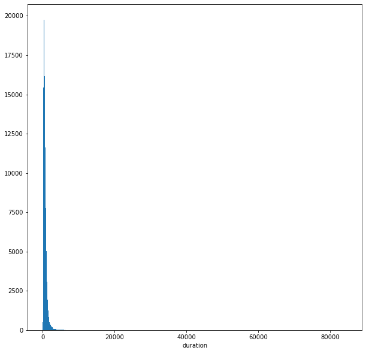

```python
# start with a standard-scaled plot f
binsize = 80
bins = np.arange(0, ford_clean['duration_sec'].max()+binsize, binsize)

plt.figure(figsize=[10,10])
plt.hist(data = ford_clean, x = 'duration_sec', bins = bins)
plt.xlabel('duration')
plt.show()
```

for this part, watch he video: 'Descriptive Statistics, Outliers and Axis Limits', as it explains what to do in almost this exact instance (although they talked about using minutes instead of seconds.)

```
(44.15704473533123, 10000.0)
```

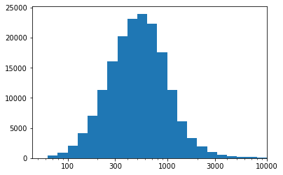

```python
bins = 10 ** np.arange(1.8, 4.9 + 0.1 , 0.1)
ticks = [100, 300, 1000, 3000, 10000]
labels = ['{}'.format(v) for v in ticks]
plt.hist(data = ford_clean, x = 'duration_sec', bins = bins)
plt.xscale('log')
plt.xticks(ticks, labels)
plt.xlim(0, 10000)
```

### Age

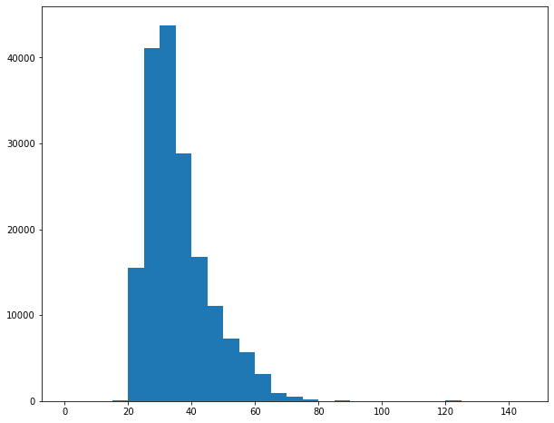

```python
# This was the initial age plot. We can see the outliers beyond 80, so at this point I returned to the wrangling phase to retrict the dataset.
plt.figure(figsize=[10, 8])
bins = np.arange(0, ford_upd['member_age'].max()+5, 5)
plt.hist(ford_upd['member_age'].dropna(), bins=bins);
plt.show()
```

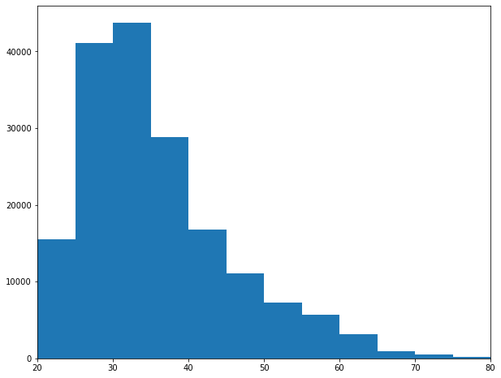

```python
# This is the updated age plot for the restricted dataset
plt.figure(figsize=[10, 8])
bins = np.arange(0, ford_clean['member_age'].max()+5, 5)
plt.hist(ford_clean['member_age'].dropna(), bins=bins);
plt.xlim(20,80)
plt.show()
```

Can see from the distribution of the ages here that it is skewed to the right, with most riders are in their early thirties. Also a clear outlier at 120 in the unscaled plot above.

```python
ford_clean[ford_clean['member_age']< 46].shape
```

```
(148549, 19)
```

```python
ford_clean[ford_clean['member_age']< 35].shape
```

```
(100444, 19)
```

```python
ford_clean.shape
```

```
(174749, 19)
```

```python
# therefore the percentage of people falling between the ages of 35 and 45 is:
print((148549-100444)/174952)
```

```
0.27496113219625956
```

### start Hour

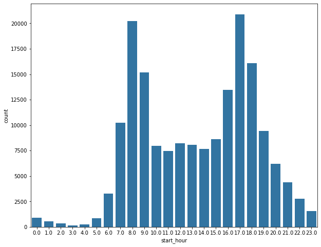

```python
# bar chart for time
plt.figure(figsize=[10,8])
base_color = sb.color_palette()[0]
sb.countplot(data=ford_clean, x='start_hour', color=base_color);
```

### Start Day

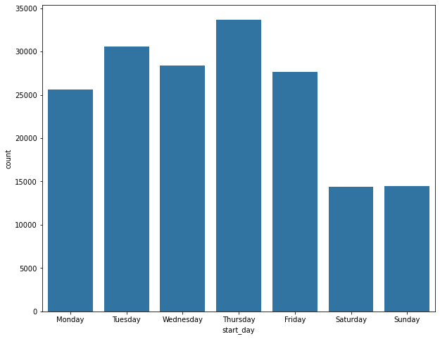

```python
plt.figure(figsize=[10,8])
base_color = sb.color_palette()[0]
sb.countplot(data=ford_clean, x='start_day', color=base_color, order=['Monday', 'Tuesday', 'Wednesday', 'Thursday', 'Friday', 'Saturday', 'Sunday']);
```

The Ford Go Bikes are much more popular during weekdays.

### Gender

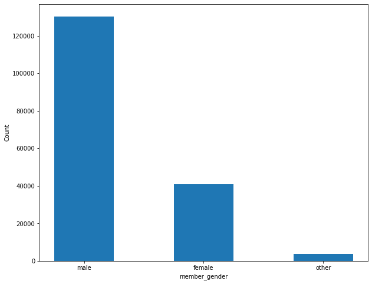

```python
# bar chart for gender
plt.figure(figsize = [10,8])
x = ford_clean['member_gender'].unique()
y = ford_clean['member_gender'].value_counts(sort=True)
plt.bar(x, y, tick_label=['male', 'female', 'other'], width =0.5)
plt.xlabel('member_gender')
plt.ylabel('Count')
plt.show()
```

Males make up majority of the dataset.

### user Type

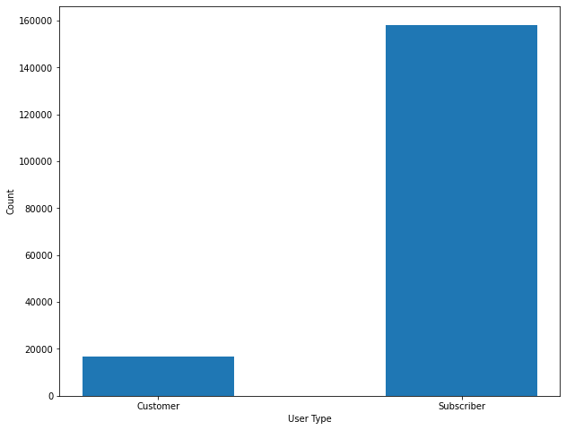

```python
# bar chart for user type
plt.figure(figsize = [10,8])
x = ford_clean['user_type'].unique()
y = ford_clean['user_type'].value_counts(sort=False)
plt.bar(x, y, width =0.5)
plt.xlabel('User Type')
plt.ylabel('Count')
plt.show()
```

Majority of users are subscribers